# ReproRes Poll Class 04

[figure not shown]

[figure not shown]

[figure not shown]

[figure not shown]

[Take the Poll](https://forms.gle/yee8TwyKn5PefPkK7)

30 Participants

### How did you engage with Chapter 3?

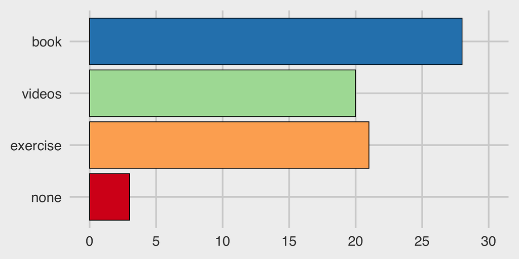

### What have you completed for the mid-term assessment?

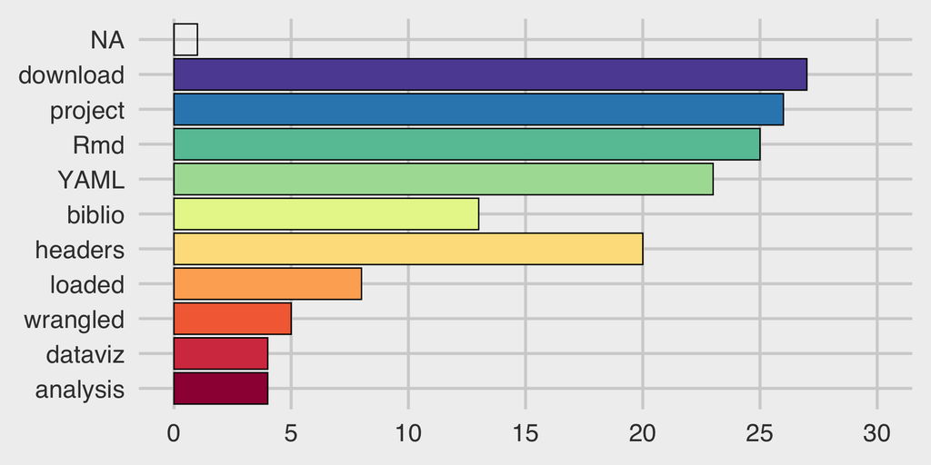

### List concepts you learned in Chapter 3 that you feel confident about.

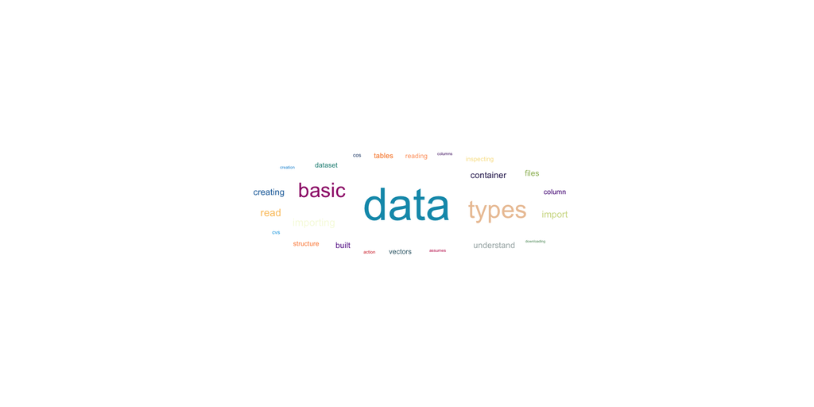

### List concepts you learned in Chapter 3 that you feel less confident about and would like reviewed in class today.

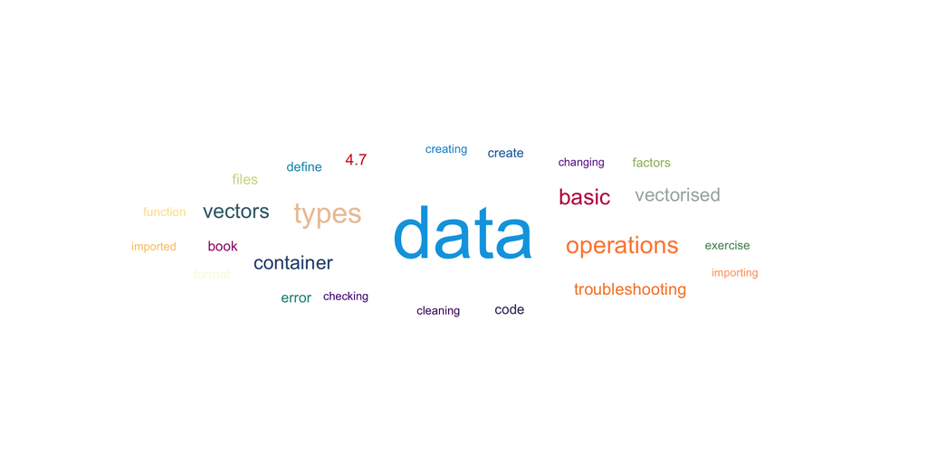

### Confident

Loading and reading data.

vectors, plotting

load built in data sets, import data, understand basic data types, understand basic container types, troubleshoot data problems

Import data from cvs files, understand the basic data types, structure data for scripting

importing, inspecting, creating data; basic data types

importing data, creating data tables

nothing…

Sufficient knowledge

reading in data, creating tibbles and columns

vectorised operation

Data Structure, Built in data, importing, inspecting, writing, basic data types, basic container types

impoirt data

downloading data thats already in R

vectors, import, export

Importing data, Data types

action on the dataset (until4.5

All

Data tables, basic data types, and basic container types

1. Tibble creation
2. Column types
3. File types, their extensions and how to read and write them in R
4. Guidelines to making my data files easier to read in with less errors
5. How to actually read an error instead of looking at it, panicking and giving up
6. Telling R what each column in a table/dataset should be when it wrongly assumes
7. Using the functions sin() and cos()

### Not Confident

Checking/cleaning the data.

loading in data

N/A

create a data table, use vectorised operations

basic container types, vectorised operations, troubleshooting

factors, vectors, vectorized operations

troubleshooting

last weeks exercise that we never got through

All of them

modify imported data

creating data tables

different data format

vectors

how to find our mid-term data files, how to define data values for plots

Terminology and Set Up

tibble function

Basic Container types, changing data types when importing data

the last part(4.7 of the book

Trouble shooting

1. Being able to troubleshoot properly even when ive read the error code